# The Energy Landscape and Renewable Transition

Fox Redmond

2026-05-04

## Introduction

Among the United Nation’s 17 key goals for sustainable development, one of its most extensive and overarching goals, is number 13: Climate Action. Its objective is to “take urgent action to combat climate change and its impacts.” The following document uses figures and tables to demonstrate some context, progress, and pathways for combating climate change. Its focus is on the current energy picture as well as the potential for transition to Renewable energy sources.

## The Current Landscape

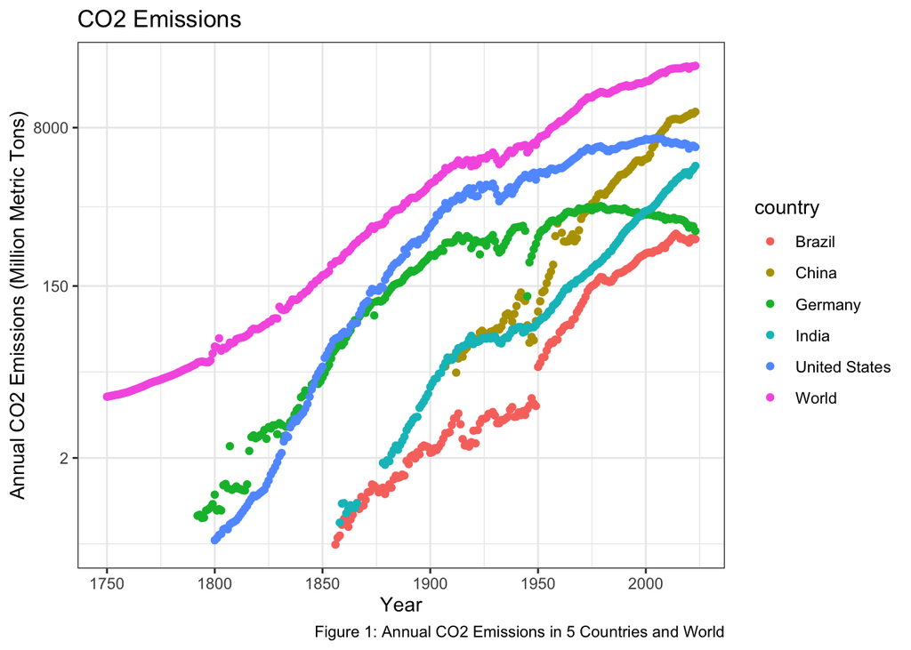

Figure 1 demonstrates the exponential rise in annual CO2 emissions dating back to 1750. Note that the plot has a logarithmic scale on its y-axis. Despite countries such as Germany and the U.S. slightly tapering their CO2 emissions in the 21st century, the overall data is extremely worrisome. According to the USDA, the largest use of energy from CO2 emitting fossil fuels in the US is:

- Transportation
- Electric power
- Industry
- Residential/Commercial
- Agriculture

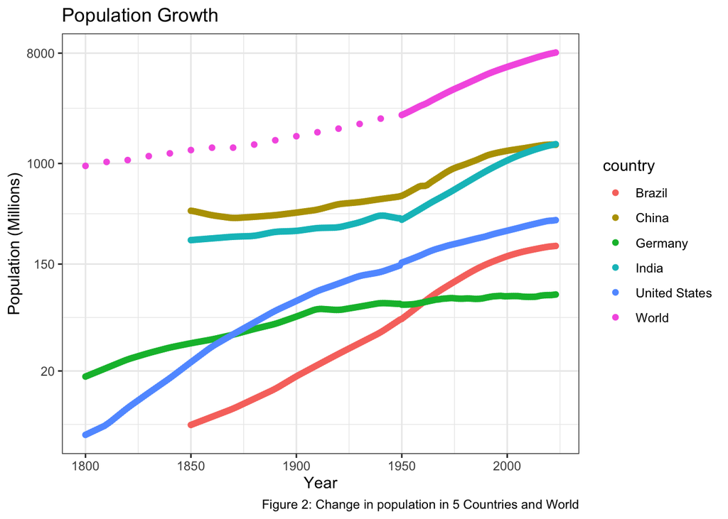

Figure 2 demonstrates the various levels of population growth in five countries in addition to the total world. The rapid growth of world population indicates a growing need for resoures and energy (and a more responsible use of them) in order to sustain everyone.

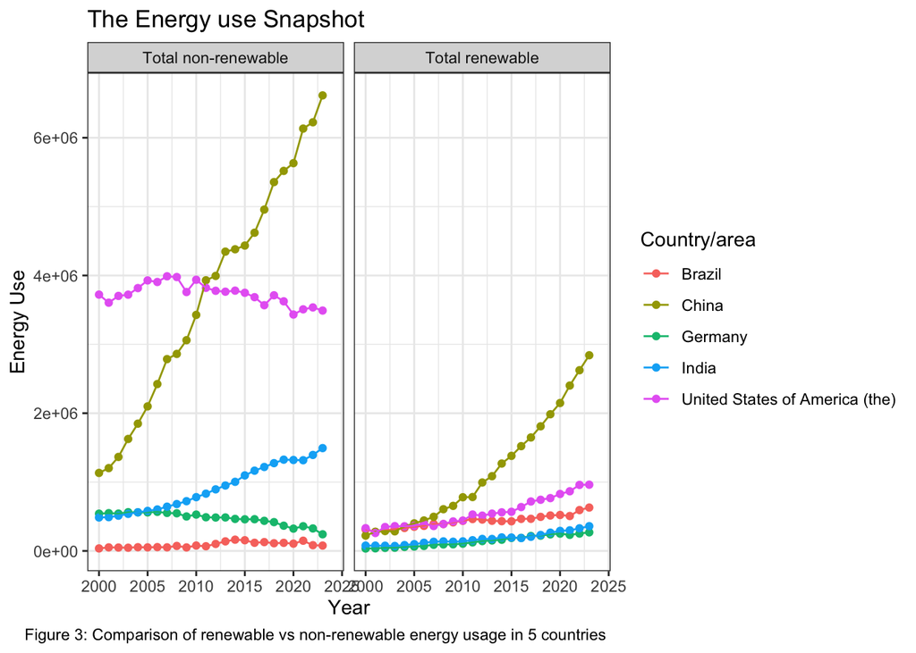

[interactive chart not shown]

**Hover over points to see more details**

Figure 4 demonstrates how plummeting lifetime costs of Onshore wind and Solar photovoltaic energy have now dipped below fossil fuel costs in a large selection of countries. This could pave the way for economically advantageous green energy transitions.

#### Breakdown of change in prices of more renewable sources

| source | year | Cost $/KwH |
| --- | --- | --- |
| Bioenergy | 2010 | 0.0781893 |
| Bioenergy | 2020 | 0.0724731 |
| Concentrated solar power | 2010 | 0.3580038 |
| Concentrated solar power | 2020 | 0.1066530 |
| Geothermal | 2010 | 0.0504453 |
| Geothermal | 2020 | 0.0542640 |
| Hydropower | 2010 | 0.0388827 |
| Hydropower | 2020 | 0.0459659 |
| Offshore wind | 2010 | 0.1878568 |
| Offshore wind | 2020 | 0.0862658 |
| Onshore wind | 2010 | 0.1162984 |
| Onshore wind | 2020 | 0.0448345 |
| Solar photovoltaic | 2010 | 0.3841601 |
| Solar photovoltaic | 2020 | 0.0641493 |

## Takeaways

As we have seen so far, our world has rapidly growing CO2 emissions in order to support a rapidly expanding population. Our unwavering reliance on fossil fuels has driven climate change to a threatening extent, which as noted by the UN’s sustainable development goals, must be checked. Luckily, advances in renewable energy technology have been able to significantly lower their lifetime energy cost. In particular wind and solar could prove vital as economically feasible green energy sources. However, as we have seen, most countries are moving too slow with this transition. In order to respond to climate change, with the agency and severity that the issue deserves, countries must take policy measures to quicken their energy transition and align with the UN’s stance, as mentioned in the Introduction.

## Data Sources

1. *Global Carbon Project* is an organization that attempts to measure green house gas emissions and deduce global budgets for key gasses, with the objective of better understanding climate change in order to combat it. [Go here to learn more](https://www.globalcarbonproject.org)
2. *IRENA* (short for International Renewable Energy Agency), is an organization that monitors renewable energy data from prices to policy in order to keep governments and the public up to date and making well informed energy decisions. [Go here to learn more](https://www.irena.org/Data/Downloads/IRENASTAT)
3. *Our World in Data* is an organization that uses a worldwide network of researchers who publish stories with the goal of making their insights on some of the biggest global issues, more easily digestible. [Go here to learn more](https://ourworldindata.org/co2-emissions)